# DDSAnalytics

Travis R. Daun, Joe Jiang, Karl J. Jurek

February 21, 2019

```r
library(httr)
library(knitr)
library(kableExtra)
library(dplyr)
```

```r
library(ggplot2)

# Reading in the 'CaseStudy2-data.csv' data file
attrition=read.csv("https://raw.githubusercontent.com/dauntr/MSDS6306_JKT_Case_Study_2/master/datasets/CaseStudy2-data.csv", header=T, stringsAsFactors=F)

# Validating there is no missing data
sapply(attrition,function(x) sum(is.na(x)))
```

```
##                      Age                Attrition           BusinessTravel
##                        0                        0                        0
##                DailyRate               Department         DistanceFromHome
##                        0                        0                        0
##                Education           EducationField            EmployeeCount
##                        0                        0                        0
##           EmployeeNumber  EnvironmentSatisfaction                   Gender
##                        0                        0                        0
##               HourlyRate           JobInvolvement                 JobLevel
##                        0                        0                        0
##                  JobRole          JobSatisfaction            MaritalStatus
##                        0                        0                        0
##            MonthlyIncome              MonthlyRate       NumCompaniesWorked
##                        0                        0                        0
##                   Over18                 OverTime        PercentSalaryHike
##                        0                        0                        0
##        PerformanceRating RelationshipSatisfaction            StandardHours
##                        0                        0                        0
##         StockOptionLevel        TotalWorkingYears    TrainingTimesLastYear
##                        0                        0                        0
##          WorkLifeBalance           YearsAtCompany       YearsInCurrentRole
##                        0                        0                        0
##  YearsSinceLastPromotion     YearsWithCurrManager
##                        0                        0
```

```r
# Changing various columns to 'factors'
attrition$BusinessTravel=as.factor(attrition$BusinessTravel)
attrition$Attrition=as.factor(attrition$Attrition)
attrition$Department=as.factor(attrition$Department)
attrition$EducationField=as.factor(attrition$EducationField)
attrition$Gender=as.factor(attrition$Gender)
attrition$JobRole=as.factor(attrition$JobRole)
attrition$MaritalStatus<- as.factor(attrition$MaritalStatus)
attrition$Over18=as.factor(attrition$Over18)
attrition$OverTime=as.factor(attrition$OverTime)
attrition$Education=as.factor(attrition$Education)
attrition$EnvironmentSatisfaction=as.factor(attrition$EnvironmentSatisfaction)
attrition$JobInvolvement=as.factor(attrition$JobInvolvement)
attrition$JobLevel=as.factor(attrition$JobLevel)
attrition$JobSatisfaction=as.factor(attrition$JobSatisfaction)
attrition$PerformanceRating=as.factor(attrition$PerformanceRating)
attrition$RelationshipSatisfaction=as.factor(attrition$RelationshipSatisfaction)
attrition$StockOptionLevel=as.factor(attrition$StockOptionLevel)
attrition$WorkLifeBalance=as.factor(attrition$WorkLifeBalance)

# Remove the 'over18' column because it only has one level (all 'yes')
attrition$Over18=NULL

# Fit full logistic model
fullmodel=glm(Attrition~., family= binomial(link="logit"), data=attrition)

# Looking at the 'fullmodel'
summary(fullmodel)
```

```
##
## Call:
## glm(formula = Attrition ~ ., family = binomial(link = "logit"),
##     data = attrition)
##
## Deviance Residuals:
##     Min       1Q   Median       3Q      Max
## -1.8141  -0.4439  -0.1942  -0.0546   3.6613
##
## Coefficients: (2 not defined because of singularities)
##                                    Estimate Std. Error z value Pr(>|z|)
## (Intercept)                      -1.031e+01  5.827e+02  -0.018 0.985886
## Age                              -3.123e-02  1.444e-02  -2.163 0.030508
## BusinessTravelTravel_Frequently   2.145e+00  4.465e-01   4.803 1.57e-06
## BusinessTravelTravel_Rarely       1.134e+00  4.122e-01   2.752 0.005919
## DailyRate                        -4.485e-04  2.353e-04  -1.906 0.056667
## DepartmentResearch & Development  1.441e+01  5.827e+02   0.025 0.980273
## DepartmentSales                   1.356e+01  5.827e+02   0.023 0.981436
## DistanceFromHome                  5.565e-02  1.162e-02   4.792 1.66e-06
## Education2                        2.535e-01  3.490e-01   0.726 0.467573
## Education3                        2.495e-01  3.060e-01   0.815 0.414819
## Education4                        2.802e-01  3.347e-01   0.837 0.402475
## Education5                        2.057e-01  6.340e-01   0.325 0.745549
## EducationFieldLife Sciences      -1.168e+00  8.913e-01  -1.311 0.189952
## EducationFieldMarketing          -6.305e-01  9.359e-01  -0.674 0.500554
## EducationFieldMedical            -1.162e+00  8.897e-01  -1.306 0.191467
## EducationFieldOther              -1.023e+00  9.619e-01  -1.064 0.287504
## EducationFieldTechnical Degree    8.993e-03  9.035e-01   0.010 0.992059
## EmployeeCount                            NA         NA      NA       NA
## EmployeeNumber                   -2.079e-04  1.628e-04  -1.277 0.201725
## EnvironmentSatisfaction2         -1.109e+00  2.960e-01  -3.746 0.000180
## EnvironmentSatisfaction3         -1.239e+00  2.719e-01  -4.558 5.17e-06
## EnvironmentSatisfaction4         -1.436e+00  2.741e-01  -5.241 1.60e-07
## GenderMale                        4.459e-01  1.967e-01   2.267 0.023365
## HourlyRate                        4.605e-03  4.772e-03   0.965 0.334495
## JobInvolvement2                  -1.284e+00  3.795e-01  -3.383 0.000718
## JobInvolvement3                  -1.576e+00  3.578e-01  -4.404 1.06e-05
## JobInvolvement4                  -2.204e+00  4.928e-01  -4.472 7.74e-06
## JobLevel2                        -1.587e+00  4.828e-01  -3.288 0.001009
## JobLevel3                         1.325e-01  7.404e-01   0.179 0.857946
```

[output cut: 99 more lines]

```
## WorkLifeBalance4                 *
## YearsAtCompany                   *
## YearsInCurrentRole               **
## YearsSinceLastPromotion          ***
## YearsWithCurrManager             **
## ---
## Signif. codes:  0 '***' 0.001 '**' 0.01 '*' 0.05 '.' 0.1 ' ' 1
##
## (Dispersion parameter for binomial family taken to be 1)
##
##     Null deviance: 1298.58  on 1469  degrees of freedom
## Residual deviance:  773.66  on 1406  degrees of freedom
## AIC: 901.66
##
## Number of Fisher Scoring iterations: 15
```

# Introduction

DDS Analytics has been charged with the task of looking into the top reasons why personnel leave the company.  
We have performed various analysis with the data set provided to come to the conclusions requested.

## Attrition Rates by Department

The following graphs display the attrition rates by department.

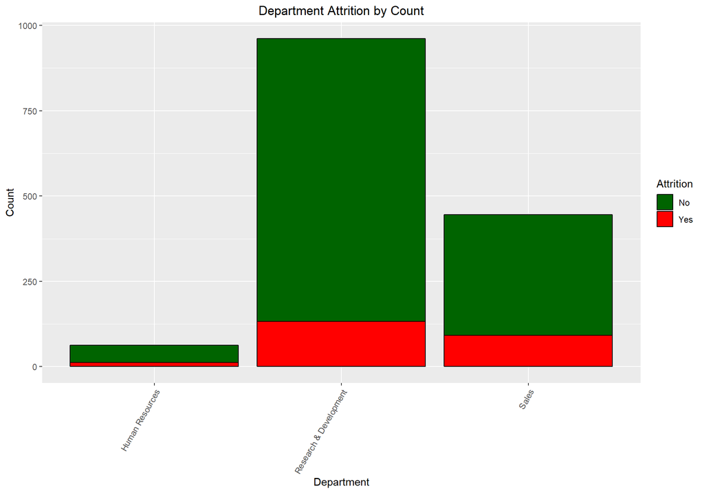

```r
# Graphs for attrition by Dept
attrition%>%ggplot() +
  geom_bar(aes(Department, fill= Attrition), color= 'black', position="stack")+
  scale_fill_manual(values=c("Yes"="red","No"="dark green"))+
  ggtitle(label='Department Attrition by Count')+
  theme(plot.title=element_text(hjust=0.5))+
  ylab('Count')+
  theme(axis.text.x=element_text(angle=60, hjust=1))
```

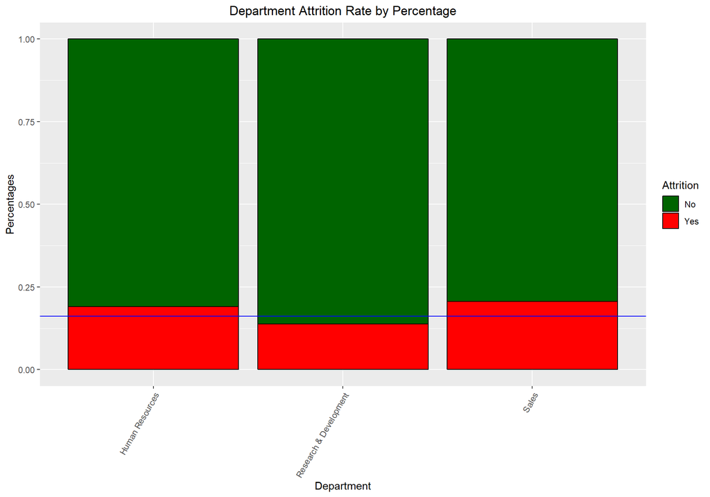

```r
attrition%>%ggplot(aes(Department, fill= Attrition)) +
  geom_bar(aes(y=(..count..)/sum(..count..)), color ='black', position="fill")+
  scale_fill_manual(values=c("Yes"="red","No"="dark green"))+
  ggtitle(label='Department Attrition Rate by Percentage')+
  theme(plot.title=element_text(hjust=0.5))+
  theme(axis.text.x=element_text(angle=60, hjust=1))+
  ylab('Percentages')+
  geom_hline(yintercept=0.1612, color="blue")
```

## Attrition Rates by Job Role

The following graphs display the attrition rates by job role.

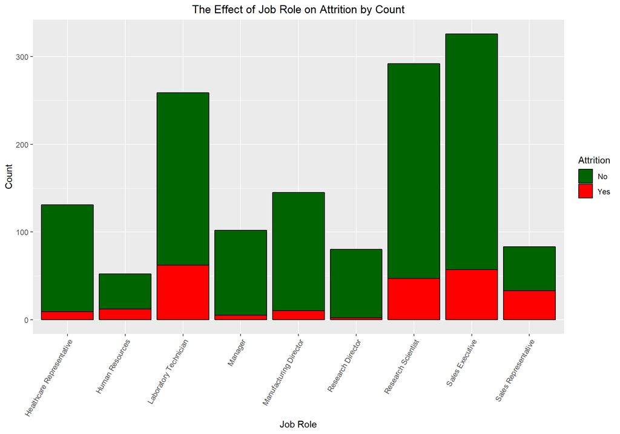

```r
# Graphs for attrition by Job Roles
attrition%>%ggplot() +
  geom_bar(aes(JobRole, fill= Attrition), color='black', position="stack")+
  scale_fill_manual(values=c("Yes"="red","No"="dark green"))+
  ggtitle(label='The Effect of Job Role on Attrition by Count')+
  theme(plot.title=element_text(hjust=0.5))+
  theme(axis.text.x=element_text(angle=60, hjust=1))+
  ylab('Count')+
  xlab('Job Role')
```

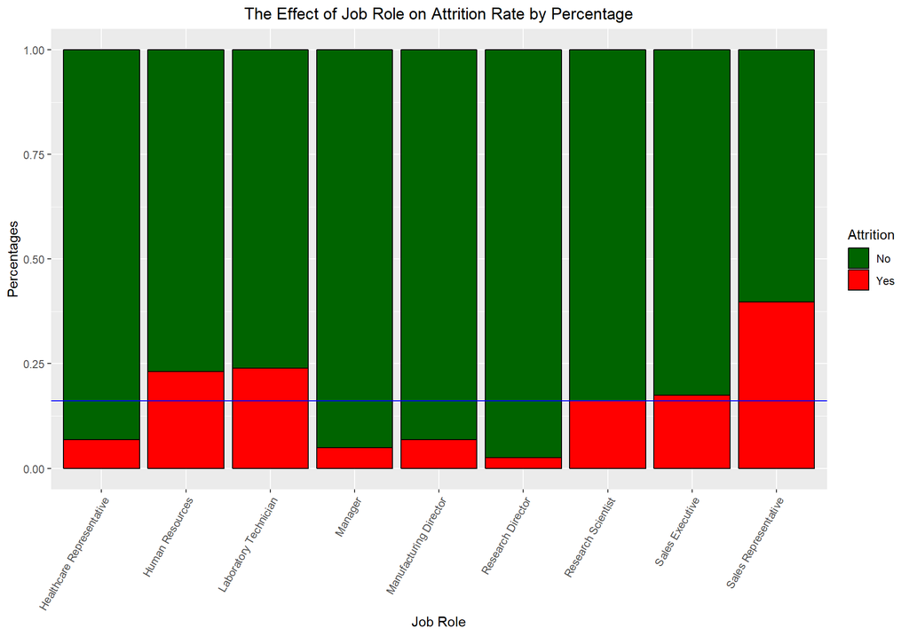

```r
attrition%>%ggplot(aes(JobRole, fill= Attrition)) +
  geom_bar(aes(y=(..count..)/sum(..count..)), color='black',position="fill")+
  scale_fill_manual(values=c("Yes"="red","No"="dark green"))+
  ggtitle(label='The Effect of Job Role on Attrition Rate by Percentage')+
  theme(plot.title=element_text(hjust=0.5))+
  theme(axis.text.x=element_text(angle=60, hjust=1))+
  ylab('Percentages')+
  xlab('Job Role')+
  geom_hline(yintercept=0.1612, color="blue")
```

## Top Three Reasons Employees Leave

1. Overtime

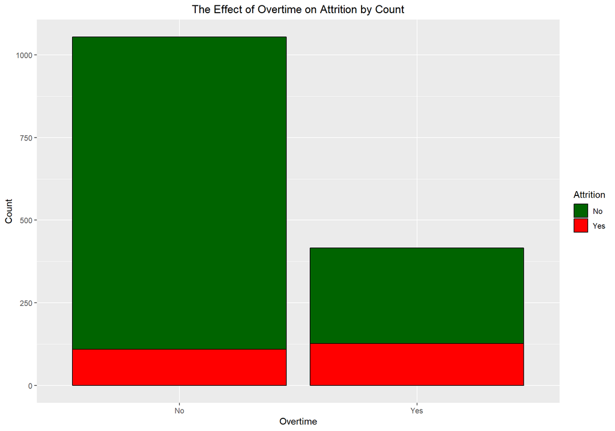

```r
# Graphs for attrition by Overtime
attrition%>%ggplot() +
  geom_bar(aes(OverTime, fill= Attrition), color='black', position="stack")+
  scale_fill_manual(values=c("Yes"="red","No"="dark green"))+
  theme(plot.title=element_text(hjust=0.5))+
  ylab('Count')+
  xlab('Overtime')+
  ggtitle(label='The Effect of Overtime on Attrition by Count')
```

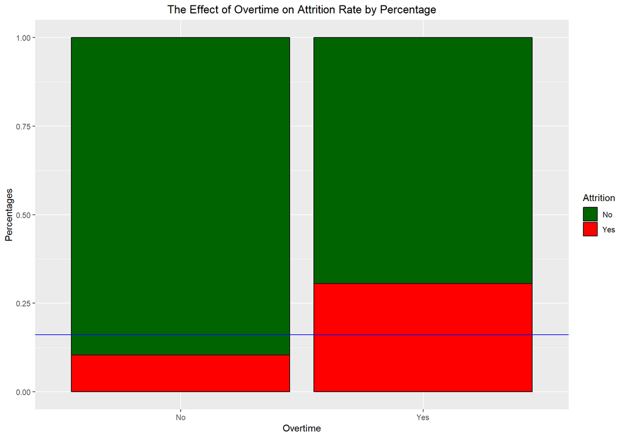

```r
attrition%>%ggplot(aes(OverTime, fill= Attrition)) +
  geom_bar(aes(y=(..count..)/sum(..count..)), color='black',position="fill")+
  scale_fill_manual(values=c("Yes"="red","No"="dark green"))+
  ggtitle(label='The Effect of Overtime on Attrition Rate by Percentage')+
  theme(plot.title=element_text(hjust=0.5))+
  ylab('Percentages')+
  xlab('Overtime')+
  geom_hline(yintercept=0.1612, color="blue")
```

2. Job Involvement

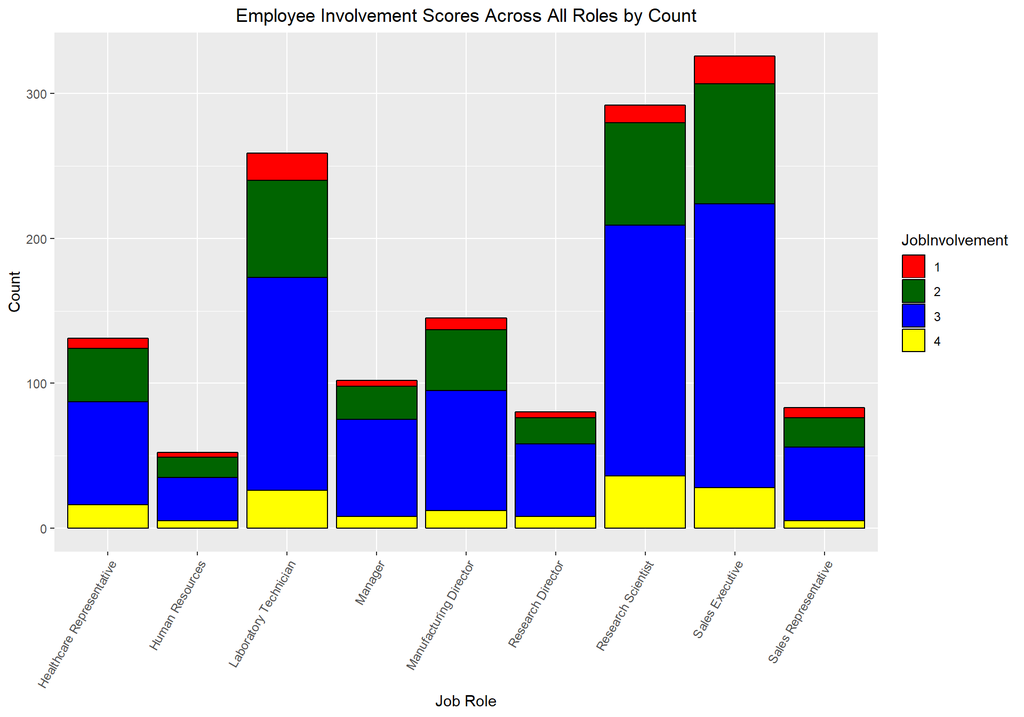

```r
# Graphs for attrition by Job Involvement
attrition%>%ggplot() +
  geom_bar(aes(x=JobRole, fill=JobInvolvement ), color='black', position="stack")+
  scale_fill_manual(values=c("1"="red","2"="dark green", '3'='blue', '4'='yellow'))+
  theme(plot.title=element_text(hjust=0.5))+
  theme(axis.text.x=element_text(angle=60, hjust=1))+
  ggtitle(label='Employee Involvement Scores Across All Roles by Count')+
  ylab('Count')+
  xlab('Job Role')
```

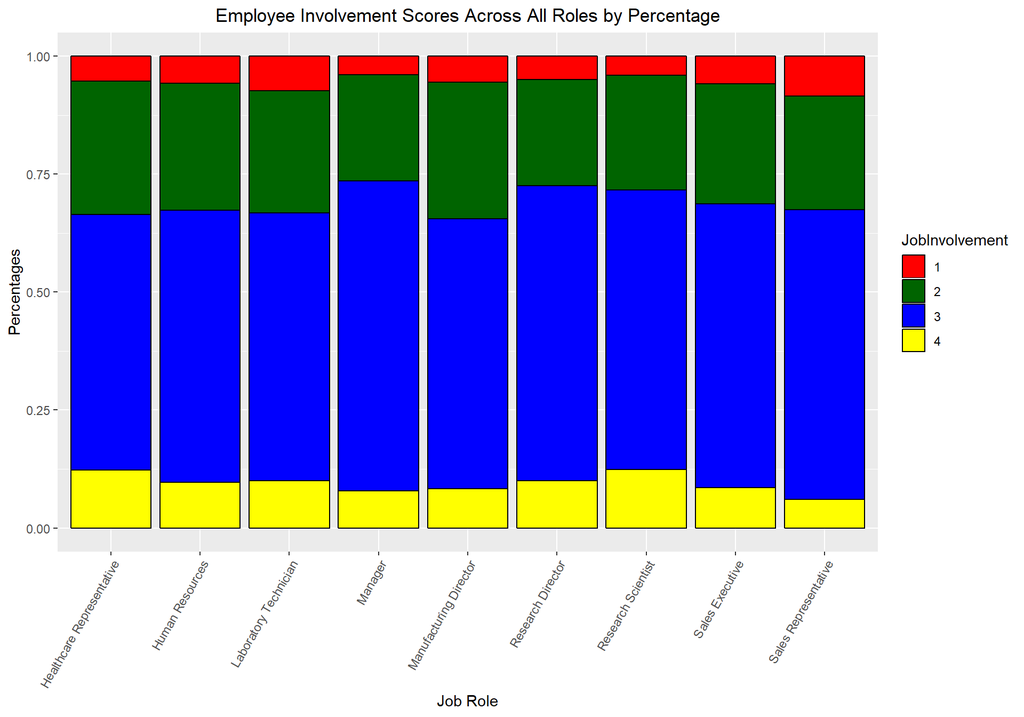

```r
attrition%>%ggplot(aes(JobRole, fill=JobInvolvement )) +
  geom_bar(aes(y=(..count..)/sum(..count..)),color ='black', position="fill")+
  scale_fill_manual(values=c("1"="red","2"="dark green", '3'='blue', '4'='yellow'))+
  ggtitle(label='Employee Involvement Scores Across All Roles by Percentage')+
  theme(plot.title=element_text(hjust=0.5))+
  theme(axis.text.x=element_text(angle=60, hjust=1))+
  ylab('Percentages')+
  xlab('Job Role')
```

3. Frequent Travel

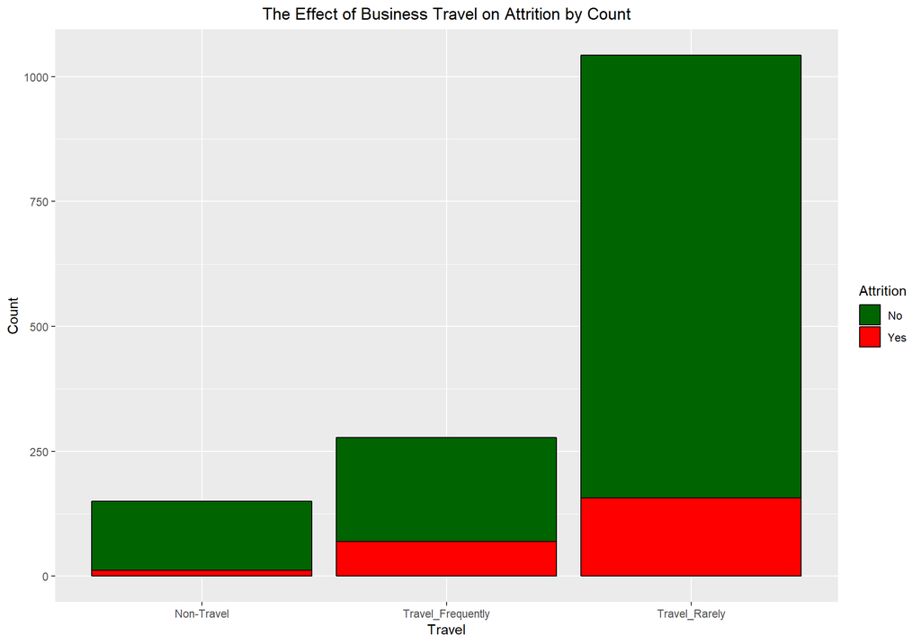

```r
# Graphs for attrition by Frequent Travel
attrition%>%ggplot() +
  geom_bar(aes(BusinessTravel, fill= Attrition), color='black', position="stack")+
  scale_fill_manual(values=c("Yes"="red","No"="dark green"))+
  ggtitle(label='The Effect of Business Travel on Attrition by Count')+
  theme(plot.title=element_text(hjust=0.5))+
  ylab('Count')+
  xlab('Travel')
```

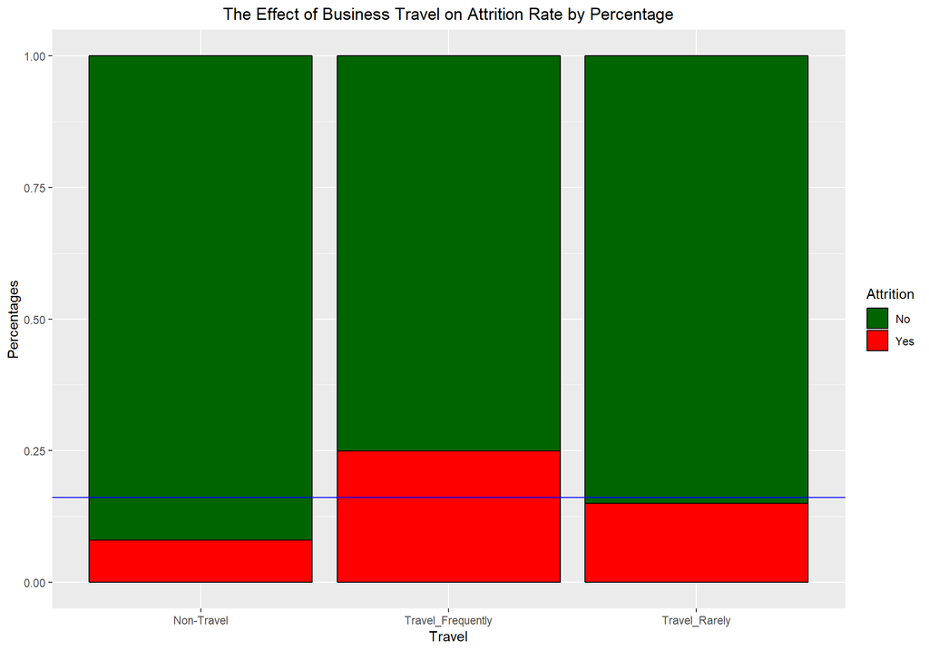

```r
attrition%>%ggplot(aes(BusinessTravel, fill= Attrition)) +
  geom_bar(aes(y=(..count..)/sum(..count..)), color='black', position="fill")+
  scale_fill_manual(values=c("Yes"="red","No"="dark green"))+
  ggtitle(label='The Effect of Business Travel on Attrition Rate by Percentage')+
  theme(plot.title=element_text(hjust=0.5))+
  ylab('Percentages')+
  geom_hline(yintercept=0.1612, color="blue")+
  ylab('Percentages')+
  xlab('Travel')
```

## Top Reasons Why Employees Stay

1. Stock Options

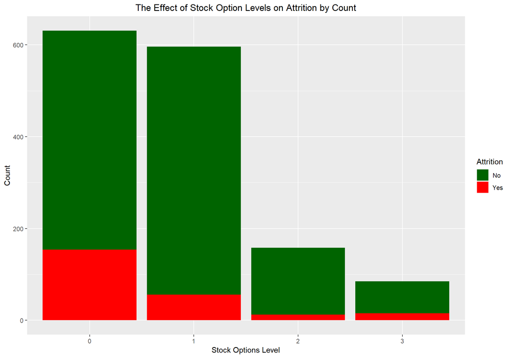

```r
# Graphs for Staying because of Stock Options
attrition%>%ggplot() +
  geom_bar(aes(StockOptionLevel, fill= Attrition), position="stack")+
  scale_fill_manual(values=c("Yes"="red","No"="dark green"))+
  ggtitle(label='The Effect of Stock Option Levels on Attrition by Count')+
  theme(plot.title=element_text(hjust=0.5))+
  ylab('Count')+
  xlab('Stock Options Level')
```

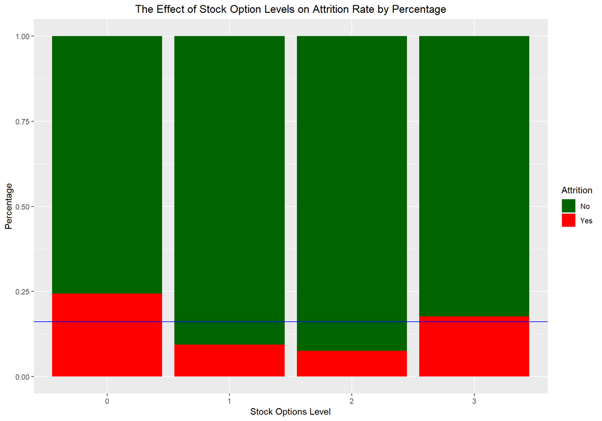

```r
attrition%>%ggplot(aes(StockOptionLevel, fill= Attrition)) +
  geom_bar(aes(y=(..count..)/sum(..count..)), position="fill")+
  scale_fill_manual(values=c("Yes"="red","No"="dark green"))+
  ggtitle(label='The Effect of Stock Option Levels on Attrition Rate by Percentage')+
  theme(plot.title=element_text(hjust=0.5))+
  ylab('Percentages')+
  geom_hline(yintercept=0.1612, color="blue")+
  ylab('Percentage')+
  xlab('Stock Options Level')
```

2. At the Company for at least three years.

[figure not shown]

```r
# Graphs for Staying because of being with the company greater than three years
attrition%>%ggplot() +
  geom_histogram(aes(x=YearsAtCompany, fill= Attrition), bins =41, color='black', position="stack")+
  scale_fill_manual(values=c("Yes"="red","No"="dark green"))+
  ggtitle(label='The Effect of Job Involvement on Attrition by Count')+
  theme(plot.title=element_text(hjust=0.5))+
  ylab('Count')+
  xlab('Years with Company')
```

[figure not shown]

```r
attrition%>%ggplot(aes(x=YearsAtCompany, fill= Attrition)) +
  geom_histogram(aes(y=(..count..)/sum(..count..)), bins =41, color ='black', position="fill")+
  scale_fill_manual(values=c("Yes"="red","No"="dark green"))+
  ggtitle(label='The Effect of Job Involvement on Attrition Rate by Percentage')+
  theme(plot.title=element_text(hjust=0.5))+
  ylab('Percentages')+
  xlab('Years with Company')+
  geom_hline(yintercept=0.1612, color="blue")
```

## Conclusion and Recommendations

1. Overtime is the most influential factor in why an employee leaves the company. You should find ways to  
improve work/life balance for your employees.  
2. If the employee does not feel a sense of involvment they will leave. A strategy should be developed to keep | employees engaged.  
3. Reduce travel time for employees as much as possible. This has a two-fold effect. First, you wil retain  
more of your employees. Second, you will reduce expenses for the company.  
4. The largest group of employees are the young and new employees. If you are able to keep to retain the  
employee past three years they will be with the company for a long period. Ways of accomplishing this are:  
A. Mentoring and more time with their manager.  
B. Offering stock options earlier or immediately when hired.

## Appendix

1. Naive Bayes Model

```r
# Installing package and library 'e1071' for Naive_Bayes
install.packages("e1071", dependencies=F, repos="http://cran.us.r-project.org")
library(e1071)

# Creating the Naive-Bayes model
Naive_Bayes_Model=naiveBayes(Attrition ~., data=attrition)

# Viewing the Naive_Bayes model
Naive_Bayes_Model
```

```
##
## Naive Bayes Classifier for Discrete Predictors
##
## Call:
## naiveBayes.default(x = X, y = Y, laplace = laplace)
##
## A-priori probabilities:
## Y
##        No       Yes
## 0.8387755 0.1612245
##
## Conditional probabilities:
##      Age
## Y         [,1]    [,2]
##   No  37.56123 8.88836
##   Yes 33.60759 9.68935
##
##      BusinessTravel
## Y     Non-Travel Travel_Frequently Travel_Rarely
##   No  0.11192214        0.16869424    0.71938362
##   Yes 0.05063291        0.29113924    0.65822785
##
##      DailyRate
## Y         [,1]     [,2]
##   No  812.5045 403.2084
##   Yes 750.3629 401.8995
##
##      Department
## Y     Human Resources Research & Development      Sales
##   No       0.04136253             0.67153285 0.28710462
##   Yes      0.05063291             0.56118143 0.38818565
##
##      DistanceFromHome
## Y          [,1]     [,2]
##   No   8.915653 8.012633
##   Yes 10.632911 8.452525
##
##      Education
## Y              1          2          3          4          5
##   No  0.11273317 0.19302514 0.38361719 0.27575020 0.03487429
```

[output cut: 133 more lines]

```
##
##      YearsInCurrentRole
## Y         [,1]     [,2]
##   No  4.484185 3.649402
##   Yes 2.902954 3.174827
##
##      YearsSinceLastPromotion
## Y         [,1]     [,2]
##   No  2.234388 3.234762
##   Yes 1.945148 3.153077
##
##      YearsWithCurrManager
## Y         [,1]     [,2]
##   No  4.367397 3.594116
##   Yes 2.852321 3.143349
```

```r
# Creating the Naive-Bayes model predictions
NB_Predictions=predict(Naive_Bayes_Model,attrition)

# Viewing the Naive_Bayes model predictions
# NOTE: Confusion matrix to check accuracy
table(NB_Predictions, attrition$Attrition)
```

```
##
## NB_Predictions   No  Yes
##            No  1020   79
##            Yes  213  158
```

2. Trees

```r
# Installing package and library 'rpart' and 'rpart.plot' for tree view
install.packages("rpart", dependencies=F, repos="http://cran.us.r-project.org")
install.packages("rpart.plot", dependencies=F, repos="http://cran.us.r-project.org")
library(rpart)

# Creating the tree
tree <- rpart(Attrition ~ Age + Education + MonthlyIncome + JobLevel + StockOptionLevel + MaritalStatus +
                 Department + BusinessTravel + DistanceFromHome + EducationField + Gender + JobRole +
                 NumCompaniesWorked + OverTime + PercentSalaryHike + TotalWorkingYears + TrainingTimesLastYear +
                 YearsAtCompany + YearsInCurrentRole + YearsSinceLastPromotion + YearsWithCurrManager +
                 EnvironmentSatisfaction + JobInvolvement + JobSatisfaction + PerformanceRating +
                 RelationshipSatisfaction + WorkLifeBalance,
                 data=attrition,  method="class")

# Viewing the summary of 'tree'
summary(tree)
```

```
## Call:
## rpart(formula = Attrition ~ Age + Education + MonthlyIncome +
##     JobLevel + StockOptionLevel + MaritalStatus + Department +
##     BusinessTravel + DistanceFromHome + EducationField + Gender +
##     JobRole + NumCompaniesWorked + OverTime + PercentSalaryHike +
##     TotalWorkingYears + TrainingTimesLastYear + YearsAtCompany +
##     YearsInCurrentRole + YearsSinceLastPromotion + YearsWithCurrManager +
##     EnvironmentSatisfaction + JobInvolvement + JobSatisfaction +
##     PerformanceRating + RelationshipSatisfaction + WorkLifeBalance,
##     data = attrition, method = "class")
##   n= 1470
##
##           CP nsplit rel error    xerror       xstd
## 1 0.05696203      0 1.0000000 1.0000000 0.05949065
## 2 0.02531646      2 0.8860759 0.9873418 0.05918480
## 3 0.01898734      4 0.8354430 0.9789030 0.05897899
## 4 0.01687764      6 0.7974684 0.9620253 0.05856272
## 5 0.01000000      9 0.7468354 0.9620253 0.05856272
##
## Variable importance
##            MonthlyIncome                 OverTime         StockOptionLevel
##                       17                       16                        8
##                  JobRole           YearsAtCompany        TotalWorkingYears
##                        7                        7                        6
##            MaritalStatus       YearsInCurrentRole               Department
##                        6                        5                        4
##  EnvironmentSatisfaction     YearsWithCurrManager                      Age
##                        4                        4                        4
##         DistanceFromHome          JobSatisfaction                Education
##                        2                        2                        2
##           EducationField                 JobLevel           JobInvolvement
##                        2                        1                        1
##          WorkLifeBalance RelationshipSatisfaction       NumCompaniesWorked
##                        1                        1                        1
##
## Node number 1: 1470 observations,    complexity param=0.05696203
##   predicted class=No   expected loss=0.1612245  P(node) =1
##     class counts:  1233   237
##    probabilities: 0.839 0.161
##   left son=2 (1054 obs) right son=3 (416 obs)
```

[output cut: 178 more lines]

```
##
## Node number 109: 13 observations
##   predicted class=Yes  expected loss=0.2307692  P(node) =0.008843537
##     class counts:     3    10
##    probabilities: 0.231 0.769
##
## Node number 216: 24 observations
##   predicted class=No   expected loss=0.25  P(node) =0.01632653
##     class counts:    18     6
##    probabilities: 0.750 0.250
##
## Node number 217: 8 observations
##   predicted class=Yes  expected loss=0.25  P(node) =0.005442177
##     class counts:     2     6
##    probabilities: 0.250 0.750
```

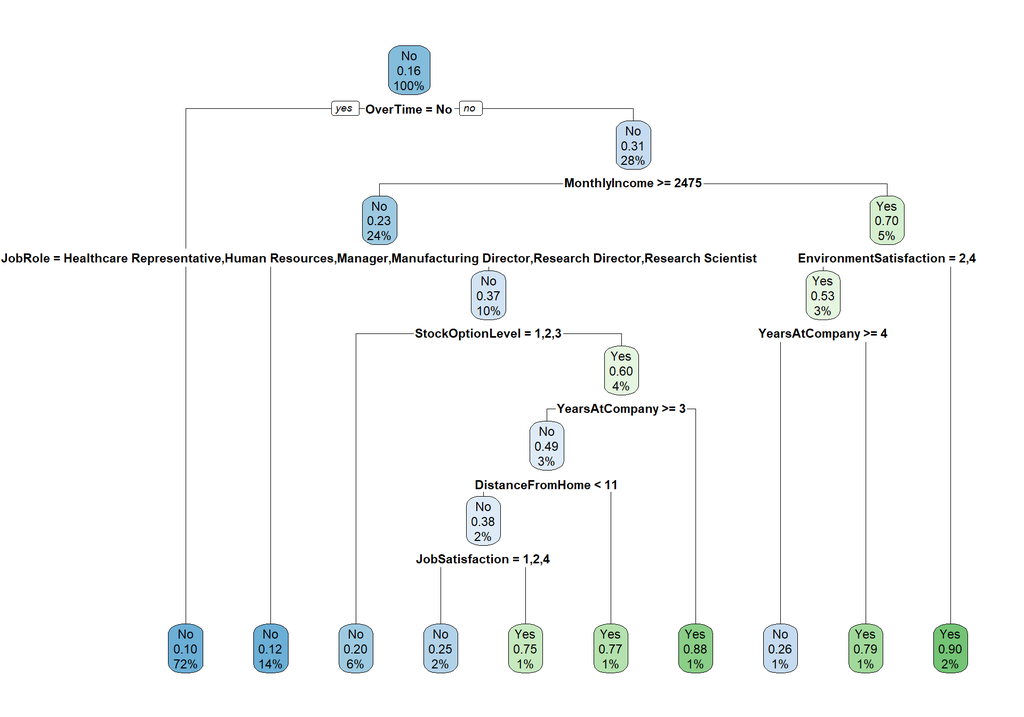

```r
#Calling the library 'rpart.plot'for plotting 'tree'
library(rpart.plot)

# Plotting 'tree'
rpart.plot(tree)
```

3. GitHub Repository  
https://github.com/dauntr/MSDS6306_JKT_Case_Study_2